# Modeling and prediction for movies

## Setup

### Load packages

```r
library(ggplot2)
library(dplyr)
library(statsr)
library(GGally)
```

### Load data

Make sure your data and R Markdown files are in the same directory. When loaded your data file will be called `movies`. Delete this note when before you submit your work.

```r
load("movies.Rdata")
```

## Part 1: Data

This dataset is comprised of data about 651 randomly sampled movies released before 2016. Part of the data is rating provided by [Rotten Tomatoes](https://www.rottentomatoes.com/) and [IMDb](http://www.imdb.com/).

Rotten Tomatoes was launched in 1998. It focuses on film reviews and contains reviews from a variety of critics across the U.S.

The Internet Movie Database (IMDb) is an online database of information related to films, television programs, and video games, it includes such data as cast, production crew, fictional characters, biographies, plot summaries, trivia and reviews, operated by IMDb.com, Inc., a subsidiary of Amazon.

### Sampling

The sampling is composed of randomly sampled U.S. movies theatrically released between 1970 and 2014. The data comes from Rotten Tomatoes and IMDb.

#### Scope of Inference

This dataset can be considered to be the result of an observational retrospective study that uses random sampling.

Based on the sampling method we can assume that it is safe to generalize for all U.S. movies given in this data.

Observational studies show associations and not causality.

## Part 2: Research question

*What factor’s make a movie popular?*

How one defines popularity is the first matter that must be taken up. Popularity will be defined as having a high audience score (audience_score) on Rotten Tomatoes or a high IMDb rating (imdb_rating) on IMDb. These two variables sound like they measure the same thing, which I will check for later.

So the question is, “What factor’s make a movie have a high imdb_rating?”

The factor’s or other variables will be taken from the data set and their relevancy will be determined.

This question if of interest as it can help production studies and investors determine which movies will be liked by movie goers.

## Part 3: Exploratory data analysis

First, lest make sure that audience_score and imdb_rating are independent.

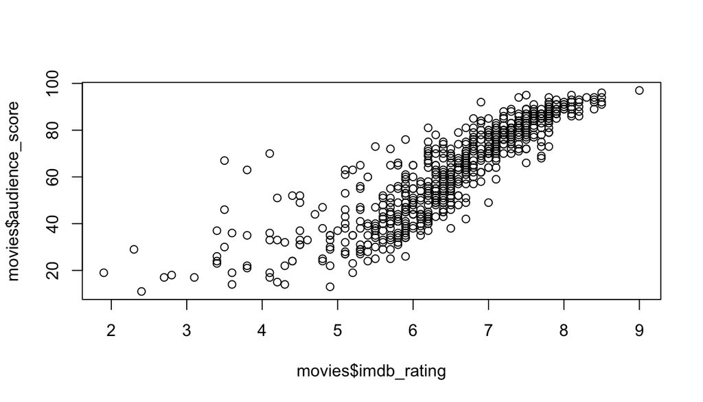

```r
plot(movies$audience_score ~ movies$imdb_rating)
```

```r
cor(movies$audience_score, movies$imdb_rating)
```

```
## [1] 0.8648652
```

As can be seen, there is a strong correlation between these two variables. This means that we don’t need to use both of them. So we are going to use imdb_rating, as there are other imbd data that we are using such as imdb_num_votes, and it’s best to use the one with the most other data connected to it.

Next, I will examine critics_score and critics_rating. critics_rating categorized interpretation of critics_score. So critics_rating will be removed from the model as well.

Next, let’s look at a summary of the imdb_rating.

```r
summary(movies$imdb_rating)
```

```
##    Min. 1st Qu.  Median    Mean 3rd Qu.    Max.
##   1.900   5.900   6.600   6.493   7.300   9.000
```

We can see that the mean is a rating of 6.493 and the top quarter of movies rate 7.300 or higher.

Next let’s look at a histogram of imdb_rating.

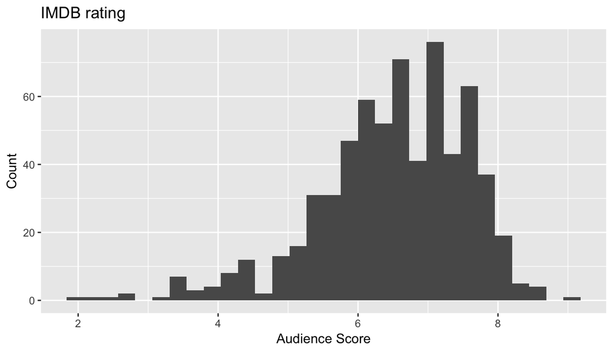

```r
ggplot(movies, aes(x = imdb_rating)) + geom_histogram() + xlab("Audience Score") + ylab("Count") + ggtitle("IMDB rating")
```

### Examinations of Response and Categorical Variables

We are first going to examine which genre’s score the best.

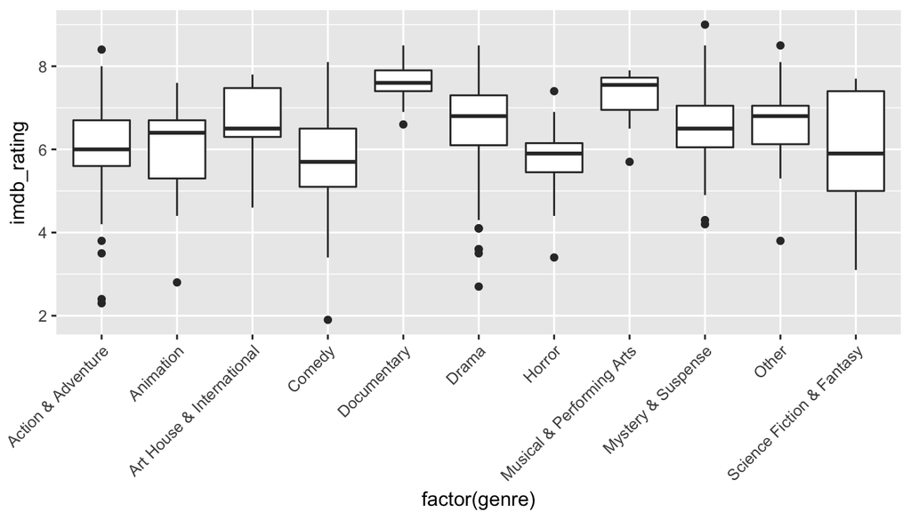

```r
ggplot(movies, aes(x=factor(genre), y=imdb_rating)) +
  geom_boxplot() +
  theme(axis.text.x = element_text(angle = 45, hjust = 1))
```

We can see that some genres are rated much higher than other genres. Documentaries and Musical & Performing Arts generally rank very high with little variation.

Next, we will see if the year of release affects how well movies perform.

```r
cor(movies$imdb_rating, movies$thtr_rel_year)
```

```
## [1] -0.03000309
```

The relationship between these two variables is very low, thus there is no correlation. The same would apply to DVD release year.

Given that the data is collected over 30 years the same actors do not show up enough times to determine whether there is a correlation between names and popularity we will remove the actor name related variables.

All movies have different titles, so there are is no way to count up which titles do better. The title column will be removed.

audience_rating is just a categorical rating of the audience score, so that will be excluded.

Most of the movies are directed by different directors, so the director columns will be removed.

I am removing the movie studio as there are too many studios that only did one to two movies. These make it hard to determine if that was a factor or not in the popularity of a movie.

Lastly, I am removing the columns that contain the URLs of these movies as that bears no relationship to their popularity.

```r
movies_aud_score <- movies[ -c(1, 6:7, 10, 15, 17:18, 25:32) ]
movies_aud_score <- na.omit(movies_aud_score)
```

Listed below are all included variables.

```r
names(movies_aud_score)
```

```
##  [1] "title_type"       "genre"            "runtime"
##  [4] "mpaa_rating"      "thtr_rel_month"   "thtr_rel_day"
##  [7] "dvd_rel_month"    "dvd_rel_day"      "imdb_rating"
## [10] "imdb_num_votes"   "critics_score"    "best_pic_nom"
## [13] "best_pic_win"     "best_actor_win"   "best_actress_win"
## [16] "best_dir_win"     "top200_box"
```

## Part 4: Modeling

We will first create the baseline model so as to be able to predict the response variables. We will include all variables to start with.

```r
model <- lm(imdb_rating ~ title_type + genre + runtime + mpaa_rating + thtr_rel_month + thtr_rel_day + dvd_rel_month + dvd_rel_day + imdb_num_votes + critics_score + best_pic_nom + best_pic_win + best_actor_win + best_actress_win + best_dir_win + top200_box, data = movies_aud_score)
summary(model)
```

```
##
## Call:
## lm(formula = imdb_rating ~ title_type + genre + runtime + mpaa_rating +
##     thtr_rel_month + thtr_rel_day + dvd_rel_month + dvd_rel_day +
##     imdb_num_votes + critics_score + best_pic_nom + best_pic_win +
##     best_actor_win + best_actress_win + best_dir_win + top200_box,
##     data = movies_aud_score)
##
## Residuals:
##      Min       1Q   Median       3Q      Max
## -2.84167 -0.32527  0.05607  0.38325  1.82268
##
## Coefficients:
##                                  Estimate Std. Error t value Pr(>|t|)
## (Intercept)                     4.551e+00  3.435e-01  13.252  < 2e-16 ***
## title_typeFeature Film         -1.184e-01  2.373e-01  -0.499  0.61809
## title_typeTV Movie             -4.808e-01  3.721e-01  -1.292  0.19672
## genreAnimation                 -3.027e-01  2.504e-01  -1.209  0.22726
## genreArt House & International  6.578e-01  2.000e-01   3.290  0.00106 **
## genreComedy                    -1.029e-01  1.080e-01  -0.953  0.34112
## genreDocumentary                7.014e-01  2.535e-01   2.767  0.00583 **
## genreDrama                      2.165e-01  9.544e-02   2.268  0.02367 *
## genreHorror                    -1.339e-01  1.592e-01  -0.841  0.40045
## genreMusical & Performing Arts  5.152e-01  2.183e-01   2.360  0.01859 *
## genreMystery & Suspense         1.465e-01  1.204e-01   1.217  0.22420
## genreOther                      3.895e-03  1.825e-01   0.021  0.98297
## genreScience Fiction & Fantasy -2.816e-01  2.392e-01  -1.177  0.23971
## runtime                         4.561e-03  1.584e-03   2.880  0.00411 **
## mpaa_ratingNC-17               -5.944e-01  4.840e-01  -1.228  0.21982
## mpaa_ratingPG                  -2.215e-01  1.808e-01  -1.225  0.22089
## mpaa_ratingPG-13               -3.039e-01  1.868e-01  -1.626  0.10437
## mpaa_ratingR                   -1.985e-01  1.803e-01  -1.101  0.27146
## mpaa_ratingUnrated             -2.701e-01  2.077e-01  -1.300  0.19404
## thtr_rel_month                  6.010e-03  7.533e-03   0.798  0.42532
## thtr_rel_day                   -9.969e-04  2.892e-03  -0.345  0.73039
## dvd_rel_month                   1.319e-02  7.665e-03   1.721  0.08571 .
## dvd_rel_day                     4.570e-03  2.859e-03   1.599  0.11043
## imdb_num_votes                  2.032e-06  2.725e-07   7.456 3.07e-13 ***
## critics_score                   2.318e-02  1.082e-03  21.414  < 2e-16 ***
## best_pic_nomyes                 1.175e-01  1.676e-01   0.701  0.48357
## best_pic_winyes                -3.360e-01  2.948e-01  -1.140  0.25481
## best_actor_winyes               1.400e-02  7.593e-02   0.184  0.85382
## best_actress_winyes            -7.112e-03  8.364e-02  -0.085  0.93226
## best_dir_winyes                 3.534e-02  1.098e-01   0.322  0.74757
## top200_boxyes                  -2.047e-01  1.781e-01  -1.150  0.25066
## ---
## Signif. codes:  0 '***' 0.001 '**' 0.01 '*' 0.05 '.' 0.1 ' ' 1
##
## Residual standard error: 0.6325 on 611 degrees of freedom
## Multiple R-squared:  0.6697, Adjusted R-squared:  0.6535
## F-statistic: 41.29 on 30 and 611 DF,  p-value: < 2.2e-16
```

We will now use backward p-value elimination to select the best model. Backward p-value selections are where we eliminate the variables with the highest p-value. I am using this method as it seems to be the simplest and most efficent way to come up with a model given the data set.

I will fist eliminate best_actress_win with a p-value of 0.93226, which is the highest p-value.

```r
model2 <- lm(imdb_rating ~ title_type + genre + runtime + mpaa_rating + thtr_rel_month + thtr_rel_day + dvd_rel_month + dvd_rel_day + imdb_num_votes + critics_score + best_pic_nom + best_pic_win + best_actor_win + best_dir_win + top200_box, data = movies_aud_score)
summary(model2)
```

```
##
## Call:
## lm(formula = imdb_rating ~ title_type + genre + runtime + mpaa_rating +
##     thtr_rel_month + thtr_rel_day + dvd_rel_month + dvd_rel_day +
##     imdb_num_votes + critics_score + best_pic_nom + best_pic_win +
##     best_actor_win + best_dir_win + top200_box, data = movies_aud_score)
##
## Residuals:
##      Min       1Q   Median       3Q      Max
## -2.84068 -0.32494  0.05393  0.38425  1.82344
##
## Coefficients:
##                                  Estimate Std. Error t value Pr(>|t|)
## (Intercept)                     4.553e+00  3.425e-01  13.293  < 2e-16 ***
## title_typeFeature Film         -1.184e-01  2.371e-01  -0.499  0.61763
## title_typeTV Movie             -4.817e-01  3.716e-01  -1.296  0.19542
## genreAnimation                 -3.038e-01  2.499e-01  -1.216  0.22460
## genreArt House & International  6.571e-01  1.996e-01   3.292  0.00105 **
## genreComedy                    -1.037e-01  1.074e-01  -0.966  0.33442
## genreDocumentary                7.009e-01  2.532e-01   2.768  0.00581 **
## genreDrama                      2.155e-01  9.465e-02   2.277  0.02315 *
## genreHorror                    -1.343e-01  1.590e-01  -0.845  0.39854
## genreMusical & Performing Arts  5.151e-01  2.181e-01   2.362  0.01850 *
## genreMystery & Suspense         1.454e-01  1.196e-01   1.216  0.22460
## genreOther                      3.305e-03  1.822e-01   0.018  0.98553
## genreScience Fiction & Fantasy -2.817e-01  2.391e-01  -1.178  0.23913
## runtime                         4.547e-03  1.573e-03   2.890  0.00399 **
## mpaa_ratingNC-17               -5.934e-01  4.834e-01  -1.228  0.22009
## mpaa_ratingPG                  -2.216e-01  1.806e-01  -1.227  0.22024
## mpaa_ratingPG-13               -3.040e-01  1.867e-01  -1.629  0.10392
## mpaa_ratingR                   -1.984e-01  1.801e-01  -1.101  0.27130
## mpaa_ratingUnrated             -2.699e-01  2.075e-01  -1.300  0.19396
## thtr_rel_month                  6.016e-03  7.527e-03   0.799  0.42449
## thtr_rel_day                   -1.006e-03  2.887e-03  -0.348  0.72777
## dvd_rel_month                   1.319e-02  7.659e-03   1.722  0.08556 .
## dvd_rel_day                     4.571e-03  2.857e-03   1.600  0.11007
## imdb_num_votes                  2.032e-06  2.723e-07   7.463 2.93e-13 ***
## critics_score                   2.318e-02  1.081e-03  21.431  < 2e-16 ***
## best_pic_nomyes                 1.161e-01  1.667e-01   0.697  0.48635
## best_pic_winyes                -3.372e-01  2.942e-01  -1.146  0.25213
## best_actor_winyes               1.363e-02  7.575e-02   0.180  0.85722
## best_dir_winyes                 3.532e-02  1.097e-01   0.322  0.74752
## top200_boxyes                  -2.055e-01  1.777e-01  -1.157  0.24786
## ---
## Signif. codes:  0 '***' 0.001 '**' 0.01 '*' 0.05 '.' 0.1 ' ' 1
##
## Residual standard error: 0.632 on 612 degrees of freedom
## Multiple R-squared:  0.6697, Adjusted R-squared:  0.654
## F-statistic: 42.79 on 29 and 612 DF,  p-value: < 2.2e-16
```

Next I will eliminate best_actor_win with a p-value of 0.85722, the highest p-value.

```r
model3 <- lm(imdb_rating ~ title_type + genre + runtime + mpaa_rating + thtr_rel_month + thtr_rel_day + dvd_rel_month + dvd_rel_day + imdb_num_votes + critics_score + best_pic_nom + best_pic_win + best_dir_win + top200_box, data = movies_aud_score)
summary(model3)
```

```
##
## Call:
## lm(formula = imdb_rating ~ title_type + genre + runtime + mpaa_rating +
##     thtr_rel_month + thtr_rel_day + dvd_rel_month + dvd_rel_day +
##     imdb_num_votes + critics_score + best_pic_nom + best_pic_win +
##     best_dir_win + top200_box, data = movies_aud_score)
##
## Residuals:
##      Min       1Q   Median       3Q      Max
## -2.84352 -0.32593  0.05214  0.38284  1.82108
##
## Coefficients:
##                                  Estimate Std. Error t value Pr(>|t|)
## (Intercept)                     4.549e+00  3.414e-01  13.325  < 2e-16 ***
## title_typeFeature Film         -1.178e-01  2.369e-01  -0.497  0.61934
## title_typeTV Movie             -4.824e-01  3.713e-01  -1.299  0.19437
## genreAnimation                 -3.028e-01  2.496e-01  -1.213  0.22555
## genreArt House & International  6.560e-01  1.994e-01   3.290  0.00106 **
## genreComedy                    -1.036e-01  1.073e-01  -0.966  0.33444
## genreDocumentary                7.015e-01  2.530e-01   2.773  0.00573 **
## genreDrama                      2.160e-01  9.453e-02   2.285  0.02265 *
## genreHorror                    -1.350e-01  1.588e-01  -0.850  0.39570
## genreMusical & Performing Arts  5.144e-01  2.179e-01   2.361  0.01855 *
## genreMystery & Suspense         1.474e-01  1.190e-01   1.238  0.21612
## genreOther                      3.568e-03  1.820e-01   0.020  0.98437
## genreScience Fiction & Fantasy -2.828e-01  2.388e-01  -1.185  0.23666
## runtime                         4.600e-03  1.544e-03   2.980  0.00300 **
## mpaa_ratingNC-17               -5.875e-01  4.819e-01  -1.219  0.22329
## mpaa_ratingPG                  -2.206e-01  1.804e-01  -1.223  0.22179
## mpaa_ratingPG-13               -3.037e-01  1.865e-01  -1.628  0.10401
## mpaa_ratingR                   -1.981e-01  1.800e-01  -1.101  0.27148
## mpaa_ratingUnrated             -2.701e-01  2.074e-01  -1.302  0.19331
## thtr_rel_month                  6.029e-03  7.521e-03   0.802  0.42303
## thtr_rel_day                   -1.000e-03  2.885e-03  -0.347  0.72901
## dvd_rel_month                   1.306e-02  7.619e-03   1.714  0.08701 .
## dvd_rel_day                     4.566e-03  2.854e-03   1.600  0.11018
## imdb_num_votes                  2.030e-06  2.719e-07   7.467 2.84e-13 ***
## critics_score                   2.317e-02  1.081e-03  21.448  < 2e-16 ***
## best_pic_nomyes                 1.197e-01  1.653e-01   0.724  0.46927
## best_pic_winyes                -3.411e-01  2.931e-01  -1.164  0.24492
## best_dir_winyes                 3.615e-02  1.095e-01   0.330  0.74137
## top200_boxyes                  -2.046e-01  1.775e-01  -1.153  0.24933
## ---
## Signif. codes:  0 '***' 0.001 '**' 0.01 '*' 0.05 '.' 0.1 ' ' 1
##
## Residual standard error: 0.6315 on 613 degrees of freedom
## Multiple R-squared:  0.6697, Adjusted R-squared:  0.6546
## F-statistic: 44.38 on 28 and 613 DF,  p-value: < 2.2e-16
```

Next I will eliminate best_dir_win with a p-value of 0.74137, the highest p-value.

```r
model4 <- lm(imdb_rating ~ title_type + genre + runtime + mpaa_rating + thtr_rel_month + thtr_rel_day + dvd_rel_month + dvd_rel_day + imdb_num_votes + critics_score + best_pic_nom + best_pic_win + top200_box, data = movies_aud_score)
summary(model4)
```

```
##
## Call:
## lm(formula = imdb_rating ~ title_type + genre + runtime + mpaa_rating +
##     thtr_rel_month + thtr_rel_day + dvd_rel_month + dvd_rel_day +
##     imdb_num_votes + critics_score + best_pic_nom + best_pic_win +
##     top200_box, data = movies_aud_score)
##
## Residuals:
##      Min       1Q   Median       3Q      Max
## -2.84495 -0.32706  0.05621  0.38222  1.82088
##
## Coefficients:
##                                  Estimate Std. Error t value Pr(>|t|)
## (Intercept)                     4.537e+00  3.393e-01  13.373  < 2e-16 ***
## title_typeFeature Film         -1.148e-01  2.366e-01  -0.485  0.62757
## title_typeTV Movie             -4.802e-01  3.710e-01  -1.294  0.19598
## genreAnimation                 -3.036e-01  2.494e-01  -1.217  0.22400
## genreArt House & International  6.539e-01  1.991e-01   3.284  0.00108 **
## genreComedy                    -1.041e-01  1.072e-01  -0.971  0.33184
## genreDocumentary                7.019e-01  2.528e-01   2.776  0.00567 **
## genreDrama                      2.149e-01  9.440e-02   2.276  0.02318 *
## genreHorror                    -1.348e-01  1.587e-01  -0.850  0.39587
## genreMusical & Performing Arts  5.137e-01  2.177e-01   2.359  0.01863 *
## genreMystery & Suspense         1.472e-01  1.190e-01   1.237  0.21649
## genreOther                      2.092e-03  1.818e-01   0.012  0.99082
## genreScience Fiction & Fantasy -2.810e-01  2.385e-01  -1.178  0.23932
## runtime                         4.681e-03  1.523e-03   3.073  0.00221 **
## mpaa_ratingNC-17               -5.883e-01  4.816e-01  -1.222  0.22229
## mpaa_ratingPG                  -2.188e-01  1.802e-01  -1.214  0.22515
## mpaa_ratingPG-13               -3.025e-01  1.864e-01  -1.623  0.10508
## mpaa_ratingR                   -1.965e-01  1.798e-01  -1.093  0.27496
## mpaa_ratingUnrated             -2.704e-01  2.072e-01  -1.305  0.19233
## thtr_rel_month                  6.084e-03  7.513e-03   0.810  0.41836
## thtr_rel_day                   -1.028e-03  2.882e-03  -0.357  0.72146
## dvd_rel_month                   1.293e-02  7.604e-03   1.700  0.08955 .
## dvd_rel_day                     4.596e-03  2.851e-03   1.612  0.10741
## imdb_num_votes                  2.032e-06  2.716e-07   7.481 2.57e-13 ***
## critics_score                   2.322e-02  1.073e-03  21.644  < 2e-16 ***
## best_pic_nomyes                 1.162e-01  1.649e-01   0.705  0.48134
## best_pic_winyes                -3.148e-01  2.819e-01  -1.117  0.26444
## top200_boxyes                  -2.063e-01  1.773e-01  -1.164  0.24488
## ---
## Signif. codes:  0 '***' 0.001 '**' 0.01 '*' 0.05 '.' 0.1 ' ' 1
##
## Residual standard error: 0.631 on 614 degrees of freedom
## Multiple R-squared:  0.6696, Adjusted R-squared:  0.6551
## F-statistic: 46.09 on 27 and 614 DF,  p-value: < 2.2e-16
```

Next I will eliminate thtr_rel_day with a p-value of 0.72146, the highest value.

```r
model5 <- lm(imdb_rating ~ title_type + genre + runtime + mpaa_rating + thtr_rel_month + dvd_rel_month + dvd_rel_day + imdb_num_votes + critics_score + best_pic_nom + best_pic_win + top200_box, data = movies_aud_score)
summary(model5)
```

```
##
## Call:
## lm(formula = imdb_rating ~ title_type + genre + runtime + mpaa_rating +
##     thtr_rel_month + dvd_rel_month + dvd_rel_day + imdb_num_votes +
##     critics_score + best_pic_nom + best_pic_win + top200_box,
##     data = movies_aud_score)
##
## Residuals:
##      Min       1Q   Median       3Q      Max
## -2.84540 -0.33022  0.05701  0.38755  1.81011
##
## Coefficients:
##                                  Estimate Std. Error t value Pr(>|t|)
## (Intercept)                     4.525e+00  3.374e-01  13.412  < 2e-16 ***
## title_typeFeature Film         -1.146e-01  2.364e-01  -0.485  0.62797
## title_typeTV Movie             -4.831e-01  3.706e-01  -1.303  0.19293
## genreAnimation                 -3.047e-01  2.492e-01  -1.222  0.22203
## genreArt House & International  6.480e-01  1.983e-01   3.268  0.00114 **
## genreComedy                    -1.029e-01  1.071e-01  -0.961  0.33697
## genreDocumentary                7.011e-01  2.526e-01   2.775  0.00568 **
## genreDrama                      2.140e-01  9.430e-02   2.270  0.02357 *
## genreHorror                    -1.370e-01  1.585e-01  -0.865  0.38763
## genreMusical & Performing Arts  5.123e-01  2.175e-01   2.355  0.01885 *
## genreMystery & Suspense         1.460e-01  1.188e-01   1.229  0.21968
## genreOther                      5.142e-03  1.815e-01   0.028  0.97741
## genreScience Fiction & Fantasy -2.755e-01  2.379e-01  -1.158  0.24720
## runtime                         4.698e-03  1.522e-03   3.087  0.00211 **
## mpaa_ratingNC-17               -5.881e-01  4.812e-01  -1.222  0.22213
## mpaa_ratingPG                  -2.206e-01  1.800e-01  -1.226  0.22069
## mpaa_ratingPG-13               -3.063e-01  1.859e-01  -1.648  0.09996 .
## mpaa_ratingR                   -1.973e-01  1.797e-01  -1.098  0.27255
## mpaa_ratingUnrated             -2.701e-01  2.071e-01  -1.304  0.19264
## thtr_rel_month                  5.761e-03  7.453e-03   0.773  0.43984
## dvd_rel_month                   1.295e-02  7.598e-03   1.704  0.08883 .
## dvd_rel_day                     4.596e-03  2.849e-03   1.613  0.10720
## imdb_num_votes                  2.026e-06  2.710e-07   7.478 2.61e-13 ***
## critics_score                   2.321e-02  1.072e-03  21.656  < 2e-16 ***
## best_pic_nomyes                 1.180e-01  1.647e-01   0.717  0.47393
## best_pic_winyes                -3.172e-01  2.816e-01  -1.126  0.26049
## top200_boxyes                  -2.054e-01  1.771e-01  -1.160  0.24660
## ---
## Signif. codes:  0 '***' 0.001 '**' 0.01 '*' 0.05 '.' 0.1 ' ' 1
##
## Residual standard error: 0.6306 on 615 degrees of freedom
## Multiple R-squared:  0.6695, Adjusted R-squared:  0.6556
## F-statistic: 47.92 on 26 and 615 DF,  p-value: < 2.2e-16
```

Next I will eliminate title_type has two high p-values, so I am removing this.

```r
model6 <- lm(imdb_rating ~ genre + runtime + mpaa_rating + thtr_rel_month + dvd_rel_month + dvd_rel_day + imdb_num_votes + critics_score + best_pic_nom + best_pic_win + top200_box, data = movies_aud_score)
summary(model6)
```

```
##
## Call:
## lm(formula = imdb_rating ~ genre + runtime + mpaa_rating + thtr_rel_month +
##     dvd_rel_month + dvd_rel_day + imdb_num_votes + critics_score +
##     best_pic_nom + best_pic_win + top200_box, data = movies_aud_score)
##
## Residuals:
##      Min       1Q   Median       3Q      Max
## -2.84241 -0.32963  0.05357  0.38917  1.82914
##
## Coefficients:
##                                  Estimate Std. Error t value Pr(>|t|)
## (Intercept)                     4.399e+00  2.393e-01  18.380  < 2e-16 ***
## genreAnimation                 -3.061e-01  2.492e-01  -1.228  0.21981
## genreArt House & International  6.533e-01  1.980e-01   3.299  0.00102 **
## genreComedy                    -1.002e-01  1.070e-01  -0.937  0.34934
## genreDocumentary                8.149e-01  1.471e-01   5.540 4.47e-08 ***
## genreDrama                      2.077e-01  9.415e-02   2.206  0.02775 *
## genreHorror                    -1.332e-01  1.584e-01  -0.841  0.40080
## genreMusical & Performing Arts  5.487e-01  2.059e-01   2.665  0.00789 **
## genreMystery & Suspense         1.456e-01  1.188e-01   1.226  0.22083
## genreOther                     -2.039e-02  1.805e-01  -0.113  0.91008
## genreScience Fiction & Fantasy -2.761e-01  2.379e-01  -1.161  0.24610
## runtime                         4.739e-03  1.521e-03   3.116  0.00192 **
## mpaa_ratingNC-17               -5.850e-01  4.812e-01  -1.216  0.22456
## mpaa_ratingPG                  -2.184e-01  1.799e-01  -1.214  0.22535
## mpaa_ratingPG-13               -3.047e-01  1.859e-01  -1.639  0.10170
## mpaa_ratingR                   -1.994e-01  1.796e-01  -1.110  0.26753
## mpaa_ratingUnrated             -2.864e-01  2.057e-01  -1.393  0.16423
## thtr_rel_month                  6.048e-03  7.449e-03   0.812  0.41716
## dvd_rel_month                   1.265e-02  7.591e-03   1.666  0.09616 .
## dvd_rel_day                     4.795e-03  2.844e-03   1.686  0.09230 .
## imdb_num_votes                  2.033e-06  2.705e-07   7.514 2.02e-13 ***
## critics_score                   2.330e-02  1.060e-03  21.975  < 2e-16 ***
## best_pic_nomyes                 1.187e-01  1.646e-01   0.721  0.47121
## best_pic_winyes                -3.238e-01  2.815e-01  -1.150  0.25057
## top200_boxyes                  -2.077e-01  1.771e-01  -1.173  0.24130
## ---
## Signif. codes:  0 '***' 0.001 '**' 0.01 '*' 0.05 '.' 0.1 ' ' 1
##
## Residual standard error: 0.6305 on 617 degrees of freedom
## Multiple R-squared:  0.6685, Adjusted R-squared:  0.6556
## F-statistic: 51.85 on 24 and 617 DF,  p-value: < 2.2e-16
```

Next I will eliminate best_pic_nom a p-value of 0.47121, the highest p-value.

```r
model7 <- lm(imdb_rating ~ genre + runtime + mpaa_rating + thtr_rel_month + dvd_rel_month + dvd_rel_day + imdb_num_votes + critics_score + best_pic_win + top200_box, data = movies_aud_score)
summary(model7)
```

```
##
## Call:
## lm(formula = imdb_rating ~ genre + runtime + mpaa_rating + thtr_rel_month +
##     dvd_rel_month + dvd_rel_day + imdb_num_votes + critics_score +
##     best_pic_win + top200_box, data = movies_aud_score)
##
## Residuals:
##      Min       1Q   Median       3Q      Max
## -2.84395 -0.32229  0.05043  0.39260  1.82894
##
## Coefficients:
##                                  Estimate Std. Error t value Pr(>|t|)
## (Intercept)                     4.377e+00  2.373e-01  18.447  < 2e-16 ***
## genreAnimation                 -3.051e-01  2.491e-01  -1.225 0.221137
## genreArt House & International  6.554e-01  1.979e-01   3.312 0.000982 ***
## genreComedy                    -9.845e-02  1.069e-01  -0.921 0.357361
## genreDocumentary                8.157e-01  1.470e-01   5.548 4.30e-08 ***
## genreDrama                      2.113e-01  9.398e-02   2.249 0.024888 *
## genreHorror                    -1.296e-01  1.583e-01  -0.819 0.413278
## genreMusical & Performing Arts  5.463e-01  2.058e-01   2.655 0.008142 **
## genreMystery & Suspense         1.475e-01  1.187e-01   1.242 0.214684
## genreOther                     -8.534e-03  1.797e-01  -0.047 0.962132
## genreScience Fiction & Fantasy -2.767e-01  2.378e-01  -1.164 0.245027
## runtime                         4.832e-03  1.515e-03   3.190 0.001493 **
## mpaa_ratingNC-17               -5.895e-01  4.809e-01  -1.226 0.220778
## mpaa_ratingPG                  -2.172e-01  1.799e-01  -1.208 0.227624
## mpaa_ratingPG-13               -3.031e-01  1.858e-01  -1.631 0.103340
## mpaa_ratingR                   -2.003e-01  1.796e-01  -1.116 0.265030
## mpaa_ratingUnrated             -2.893e-01  2.055e-01  -1.408 0.159728
## thtr_rel_month                  6.749e-03  7.383e-03   0.914 0.361000
## dvd_rel_month                   1.282e-02  7.584e-03   1.690 0.091526 .
## dvd_rel_day                     4.851e-03  2.842e-03   1.707 0.088285 .
## imdb_num_votes                  2.058e-06  2.682e-07   7.672 6.62e-14 ***
## critics_score                   2.339e-02  1.053e-03  22.207  < 2e-16 ***
## best_pic_winyes                -2.417e-01  2.574e-01  -0.939 0.348040
## top200_boxyes                  -2.111e-01  1.770e-01  -1.193 0.233426
## ---
## Signif. codes:  0 '***' 0.001 '**' 0.01 '*' 0.05 '.' 0.1 ' ' 1
##
## Residual standard error: 0.6303 on 618 degrees of freedom
## Multiple R-squared:  0.6683, Adjusted R-squared:  0.6559
## F-statistic: 54.12 on 23 and 618 DF,  p-value: < 2.2e-16
```

Next I will eliminate best_pic_win with a p-value of 0.348040.

```r
model8 <- lm(imdb_rating ~ genre + runtime + mpaa_rating + thtr_rel_month + dvd_rel_month + dvd_rel_day + imdb_num_votes + critics_score + top200_box, data = movies_aud_score)
summary(model8)
```

```
##
## Call:
## lm(formula = imdb_rating ~ genre + runtime + mpaa_rating + thtr_rel_month +
##     dvd_rel_month + dvd_rel_day + imdb_num_votes + critics_score +
##     top200_box, data = movies_aud_score)
##
## Residuals:
##      Min       1Q   Median       3Q      Max
## -2.83923 -0.33219  0.05419  0.39312  1.83167
##
## Coefficients:
##                                  Estimate Std. Error t value Pr(>|t|)
## (Intercept)                     4.396e+00  2.364e-01  18.595  < 2e-16 ***
## genreAnimation                 -3.056e-01  2.491e-01  -1.227  0.22027
## genreArt House & International  6.502e-01  1.978e-01   3.287  0.00107 **
## genreComedy                    -1.049e-01  1.067e-01  -0.983  0.32595
## genreDocumentary                8.110e-01  1.469e-01   5.520 5.00e-08 ***
## genreDrama                      2.079e-01  9.390e-02   2.214  0.02720 *
## genreHorror                    -1.351e-01  1.581e-01  -0.855  0.39309
## genreMusical & Performing Arts  5.468e-01  2.057e-01   2.658  0.00807 **
## genreMystery & Suspense         1.445e-01  1.187e-01   1.217  0.22389
## genreOther                     -2.267e-03  1.795e-01  -0.013  0.98993
## genreScience Fiction & Fantasy -2.755e-01  2.377e-01  -1.159  0.24693
## runtime                         4.683e-03  1.506e-03   3.109  0.00196 **
## mpaa_ratingNC-17               -5.882e-01  4.809e-01  -1.223  0.22176
## mpaa_ratingPG                  -2.191e-01  1.798e-01  -1.218  0.22361
## mpaa_ratingPG-13               -2.980e-01  1.857e-01  -1.604  0.10912
## mpaa_ratingR                   -1.980e-01  1.795e-01  -1.103  0.27060
## mpaa_ratingUnrated             -2.869e-01  2.055e-01  -1.396  0.16323
## thtr_rel_month                  6.858e-03  7.381e-03   0.929  0.35322
## dvd_rel_month                   1.333e-02  7.564e-03   1.763  0.07841 .
## dvd_rel_day                     4.689e-03  2.836e-03   1.653  0.09877 .
## imdb_num_votes                  1.991e-06  2.585e-07   7.701 5.36e-14 ***
## critics_score                   2.335e-02  1.052e-03  22.189  < 2e-16 ***
## top200_boxyes                  -2.083e-01  1.769e-01  -1.178  0.23942
## ---
## Signif. codes:  0 '***' 0.001 '**' 0.01 '*' 0.05 '.' 0.1 ' ' 1
##
## Residual standard error: 0.6302 on 619 degrees of freedom
## Multiple R-squared:  0.6678, Adjusted R-squared:  0.656
## F-statistic: 56.56 on 22 and 619 DF,  p-value: < 2.2e-16
```

Next I will eliminate thtr_rel_month with a p-value of 0.35322.

```r
model9 <- lm(imdb_rating ~ genre + runtime + mpaa_rating + top200_box + dvd_rel_month + dvd_rel_day + imdb_num_votes + critics_score, data = movies_aud_score)
summary(model9)
```

```
##
## Call:
## lm(formula = imdb_rating ~ genre + runtime + mpaa_rating + top200_box +
##     dvd_rel_month + dvd_rel_day + imdb_num_votes + critics_score,
##     data = movies_aud_score)
##
## Residuals:
##     Min      1Q  Median      3Q     Max
## -2.8405 -0.3151  0.0567  0.3918  1.8509
##
## Coefficients:
##                                  Estimate Std. Error t value Pr(>|t|)
## (Intercept)                     4.415e+00  2.354e-01  18.753  < 2e-16 ***
## genreAnimation                 -2.974e-01  2.489e-01  -1.195 0.232632
## genreArt House & International  6.536e-01  1.978e-01   3.305 0.001004 **
## genreComedy                    -1.006e-01  1.065e-01  -0.944 0.345531
## genreDocumentary                8.145e-01  1.469e-01   5.545 4.34e-08 ***
## genreDrama                      2.069e-01  9.389e-02   2.204 0.027915 *
## genreHorror                    -1.334e-01  1.581e-01  -0.844 0.399273
## genreMusical & Performing Arts  5.491e-01  2.057e-01   2.669 0.007805 **
## genreMystery & Suspense         1.390e-01  1.185e-01   1.173 0.241328
## genreOther                     -1.091e-02  1.793e-01  -0.061 0.951495
## genreScience Fiction & Fantasy -2.803e-01  2.376e-01  -1.180 0.238617
## runtime                         4.985e-03  1.470e-03   3.391 0.000741 ***
## mpaa_ratingNC-17               -5.931e-01  4.808e-01  -1.233 0.217867
## mpaa_ratingPG                  -2.169e-01  1.798e-01  -1.207 0.228042
## mpaa_ratingPG-13               -3.018e-01  1.856e-01  -1.625 0.104565
## mpaa_ratingR                   -1.959e-01  1.795e-01  -1.092 0.275413
## mpaa_ratingUnrated             -2.895e-01  2.055e-01  -1.409 0.159285
## top200_boxyes                  -1.997e-01  1.767e-01  -1.131 0.258624
## dvd_rel_month                   1.218e-02  7.460e-03   1.633 0.103064
## dvd_rel_day                     4.766e-03  2.835e-03   1.681 0.093175 .
## imdb_num_votes                  1.999e-06  2.583e-07   7.739 4.10e-14 ***
## critics_score                   2.335e-02  1.052e-03  22.188  < 2e-16 ***
## ---
## Signif. codes:  0 '***' 0.001 '**' 0.01 '*' 0.05 '.' 0.1 ' ' 1
##
## Residual standard error: 0.6301 on 620 degrees of freedom
## Multiple R-squared:  0.6673, Adjusted R-squared:  0.656
## F-statistic: 59.22 on 21 and 620 DF,  p-value: < 2.2e-16
```

Next I will eliminate top200_box with a p-value of 0.258624.

```r
model10 <- lm(imdb_rating ~ genre + runtime + mpaa_rating + dvd_rel_month + dvd_rel_day + imdb_num_votes + critics_score, data = movies_aud_score)
summary(model10)
```

```
##
## Call:
## lm(formula = imdb_rating ~ genre + runtime + mpaa_rating + dvd_rel_month +
##     dvd_rel_day + imdb_num_votes + critics_score, data = movies_aud_score)
##
## Residuals:
##      Min       1Q   Median       3Q      Max
## -2.83573 -0.31046  0.05005  0.39153  1.84977
##
## Coefficients:
##                                  Estimate Std. Error t value Pr(>|t|)
## (Intercept)                     4.396e+00  2.349e-01  18.716  < 2e-16 ***
## genreAnimation                 -2.692e-01  2.477e-01  -1.087 0.277556
## genreArt House & International  6.607e-01  1.977e-01   3.342 0.000882 ***
## genreComedy                    -9.258e-02  1.063e-01  -0.871 0.384286
## genreDocumentary                8.251e-01  1.466e-01   5.628 2.76e-08 ***
## genreDrama                      2.154e-01  9.361e-02   2.301 0.021719 *
## genreHorror                    -1.273e-01  1.581e-01  -0.806 0.420743
## genreMusical & Performing Arts  5.608e-01  2.055e-01   2.729 0.006535 **
## genreMystery & Suspense         1.481e-01  1.183e-01   1.252 0.210990
## genreOther                     -3.999e-03  1.792e-01  -0.022 0.982205
## genreScience Fiction & Fantasy -2.877e-01  2.376e-01  -1.211 0.226387
## runtime                         4.896e-03  1.468e-03   3.334 0.000906 ***
## mpaa_ratingNC-17               -5.678e-01  4.804e-01  -1.182 0.237692
## mpaa_ratingPG                  -2.003e-01  1.792e-01  -1.117 0.264258
## mpaa_ratingPG-13               -2.778e-01  1.845e-01  -1.506 0.132631
## mpaa_ratingR                   -1.690e-01  1.779e-01  -0.950 0.342696
## mpaa_ratingUnrated             -2.658e-01  2.044e-01  -1.300 0.194009
## dvd_rel_month                   1.211e-02  7.462e-03   1.624 0.104975
## dvd_rel_day                     4.750e-03  2.835e-03   1.675 0.094343 .
## imdb_num_votes                  1.928e-06  2.507e-07   7.691 5.75e-14 ***
## critics_score                   2.330e-02  1.052e-03  22.155  < 2e-16 ***
## ---
## Signif. codes:  0 '***' 0.001 '**' 0.01 '*' 0.05 '.' 0.1 ' ' 1
##
## Residual standard error: 0.6303 on 621 degrees of freedom
## Multiple R-squared:  0.6666, Adjusted R-squared:  0.6559
## F-statistic: 62.09 on 20 and 621 DF,  p-value: < 2.2e-16
```

Next I will eliminate dvd_rel_month with a p-value of 0.104975.

```r
model11 <- lm(imdb_rating ~ genre + runtime + mpaa_rating + dvd_rel_day + imdb_num_votes + critics_score, data = movies_aud_score)
summary(model11)
```

```
##
## Call:
## lm(formula = imdb_rating ~ genre + runtime + mpaa_rating + dvd_rel_day +
##     imdb_num_votes + critics_score, data = movies_aud_score)
##
## Residuals:
##      Min       1Q   Median       3Q      Max
## -2.84352 -0.31379  0.04863  0.38703  1.79041
##
## Coefficients:
##                                  Estimate Std. Error t value Pr(>|t|)
## (Intercept)                     4.481e+00  2.293e-01  19.540  < 2e-16 ***
## genreAnimation                 -2.854e-01  2.478e-01  -1.152 0.249907
## genreArt House & International  6.641e-01  1.980e-01   3.355 0.000842 ***
## genreComedy                    -1.023e-01  1.063e-01  -0.963 0.336058
## genreDocumentary                8.260e-01  1.468e-01   5.627 2.78e-08 ***
## genreDrama                      2.069e-01  9.358e-02   2.211 0.027373 *
## genreHorror                    -1.304e-01  1.583e-01  -0.824 0.410290
## genreMusical & Performing Arts  5.449e-01  2.055e-01   2.651 0.008225 **
## genreMystery & Suspense         1.404e-01  1.183e-01   1.186 0.235918
## genreOther                     -1.387e-02  1.793e-01  -0.077 0.938366
## genreScience Fiction & Fantasy -2.740e-01  2.378e-01  -1.152 0.249625
## runtime                         4.807e-03  1.469e-03   3.272 0.001128 **
## mpaa_ratingNC-17               -5.211e-01  4.802e-01  -1.085 0.278184
## mpaa_ratingPG                  -1.960e-01  1.794e-01  -1.092 0.275055
## mpaa_ratingPG-13               -2.717e-01  1.847e-01  -1.471 0.141707
## mpaa_ratingR                   -1.609e-01  1.781e-01  -0.903 0.366695
## mpaa_ratingUnrated             -2.595e-01  2.047e-01  -1.268 0.205368
## dvd_rel_day                     4.643e-03  2.838e-03   1.636 0.102400
## imdb_num_votes                  1.943e-06  2.509e-07   7.746 3.88e-14 ***
## critics_score                   2.333e-02  1.053e-03  22.166  < 2e-16 ***
## ---
## Signif. codes:  0 '***' 0.001 '**' 0.01 '*' 0.05 '.' 0.1 ' ' 1
##
## Residual standard error: 0.6311 on 622 degrees of freedom
## Multiple R-squared:  0.6652, Adjusted R-squared:  0.655
## F-statistic: 65.05 on 19 and 622 DF,  p-value: < 2.2e-16
```

Next I will eliminate dvd_rel_day with a p-value of 0.102400.

```r
model12 <- lm(imdb_rating ~ genre + runtime + mpaa_rating + imdb_num_votes + critics_score, data = movies_aud_score)
summary(model12)
```

```
##
## Call:
## lm(formula = imdb_rating ~ genre + runtime + mpaa_rating + imdb_num_votes +
##     critics_score, data = movies_aud_score)
##
## Residuals:
##      Min       1Q   Median       3Q      Max
## -2.86312 -0.31089  0.03565  0.39151  1.83275
##
## Coefficients:
##                                  Estimate Std. Error t value Pr(>|t|)
## (Intercept)                     4.540e+00  2.267e-01  20.024  < 2e-16 ***
## genreAnimation                 -2.735e-01  2.480e-01  -1.103 0.270558
## genreArt House & International  6.672e-01  1.982e-01   3.366 0.000809 ***
## genreComedy                    -9.828e-02  1.064e-01  -0.924 0.356084
## genreDocumentary                8.341e-01  1.469e-01   5.678 2.09e-08 ***
## genreDrama                      2.191e-01  9.341e-02   2.346 0.019299 *
## genreHorror                    -1.302e-01  1.585e-01  -0.822 0.411535
## genreMusical & Performing Arts  5.707e-01  2.052e-01   2.781 0.005585 **
## genreMystery & Suspense         1.484e-01  1.184e-01   1.253 0.210503
## genreOther                      2.374e-03  1.793e-01   0.013 0.989441
## genreScience Fiction & Fantasy -2.562e-01  2.378e-01  -1.077 0.281838
## runtime                         4.813e-03  1.471e-03   3.272 0.001129 **
## mpaa_ratingNC-17               -4.932e-01  4.805e-01  -1.026 0.305132
## mpaa_ratingPG                  -1.932e-01  1.797e-01  -1.075 0.282681
## mpaa_ratingPG-13               -2.629e-01  1.848e-01  -1.422 0.155437
## mpaa_ratingR                   -1.553e-01  1.783e-01  -0.871 0.384084
## mpaa_ratingUnrated             -2.505e-01  2.049e-01  -1.223 0.221853
## imdb_num_votes                  1.940e-06  2.512e-07   7.721 4.63e-14 ***
## critics_score                   2.325e-02  1.053e-03  22.082  < 2e-16 ***
## ---
## Signif. codes:  0 '***' 0.001 '**' 0.01 '*' 0.05 '.' 0.1 ' ' 1
##
## Residual standard error: 0.632 on 623 degrees of freedom
## Multiple R-squared:  0.6638, Adjusted R-squared:  0.6541
## F-statistic: 68.33 on 18 and 623 DF,  p-value: < 2.2e-16
```

Next, we perform an ANOVA test which allows us to see possible associations between independent variables and the dependent variable.

```r
anova(model12)
```

```
## Analysis of Variance Table
##
## Response: imdb_rating
##                 Df  Sum Sq Mean Sq  F value    Pr(>F)
## genre           10 164.811  16.481  41.2686 < 2.2e-16 ***
## runtime          1  36.597  36.597  91.6385 < 2.2e-16 ***
## mpaa_rating      5  15.675   3.135   7.8502 3.512e-07 ***
## imdb_num_votes   1  79.363  79.363 198.7254 < 2.2e-16 ***
## critics_score    1 194.741 194.741 487.6303 < 2.2e-16 ***
## Residuals      623 248.802   0.399
## ---
## Signif. codes:  0 '***' 0.001 '**' 0.01 '*' 0.05 '.' 0.1 ' ' 1
```

The anova test shows that all varables are significant predictors based on thier P-values.

## Part 5: Prediction

The next step is to test a movie with a prediction. We have selected Dr. Strange as the movie to run our prediction on.

```r
dr_strange <- data.frame(title_type="Feature Film",
                     genre="Action & Adventure",
                     runtime=115,
                     mpaa_rating="PG-13",
                     imdb_rating=7.6,
                     critics_rating="Certified Fresh",
                     critics_score=90,
                     audience_rating="Upright",
                     audience_score=86,
                     best_pic_nom="no",
                     best_pic_win="no",
                     best_actor_win="no",
                     best_actress_win="no",
                     best_dir_win="no",
                     top200_box="yes",
                     imdb_num_votes=312799)
prediction_dr_strange <- predict(model12, newdata=dr_strange, interval="confidence")
prediction_dr_strange
```

```
##        fit      lwr     upr
## 1 7.529869 7.304988 7.75475
```

The upper value of 7.75475 is greater than the actual score of 7.6, while the fit value was slightly lower than 7.6.

## Part 6: Conclusion

The model that was created here, based on this one test is fairly accurate. However, I’m not sure how useful this model is as it requires that a movie already has critical review before success is determined. A more useful model might predict critic reviews based on factors that exist during preproduction, which will help production companies to make more successful movies in general.